# Analysis of News Articles

# Appendices

## a) Regression Model

### Rationale behind log transformation of dependent variable

Below are the model plots for a linear regression model with a non-transformed dependent variable

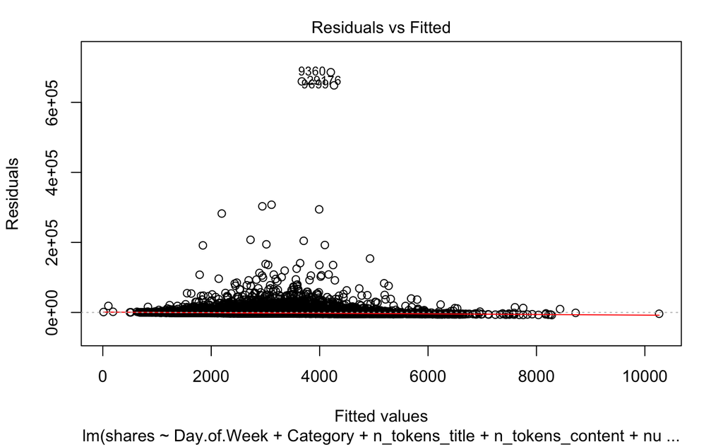

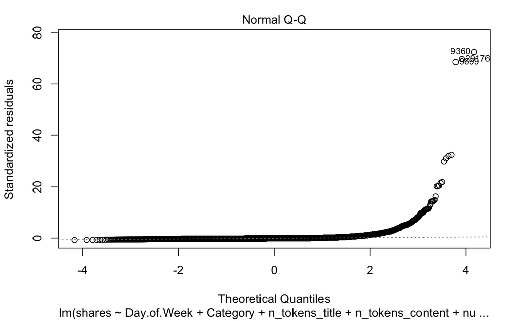

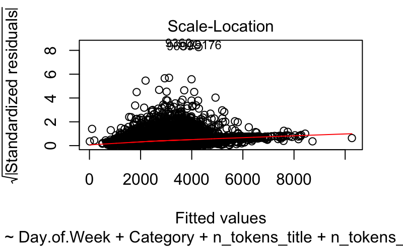

We observe the following:

- It is not clear if linearity holds because the range of residuals is very high, as seen in the fitted values vs residuals
- Constant varaince assumption does not appear to be met as seen from the scale-location plot

Here are the model plots for a log transformed variable:

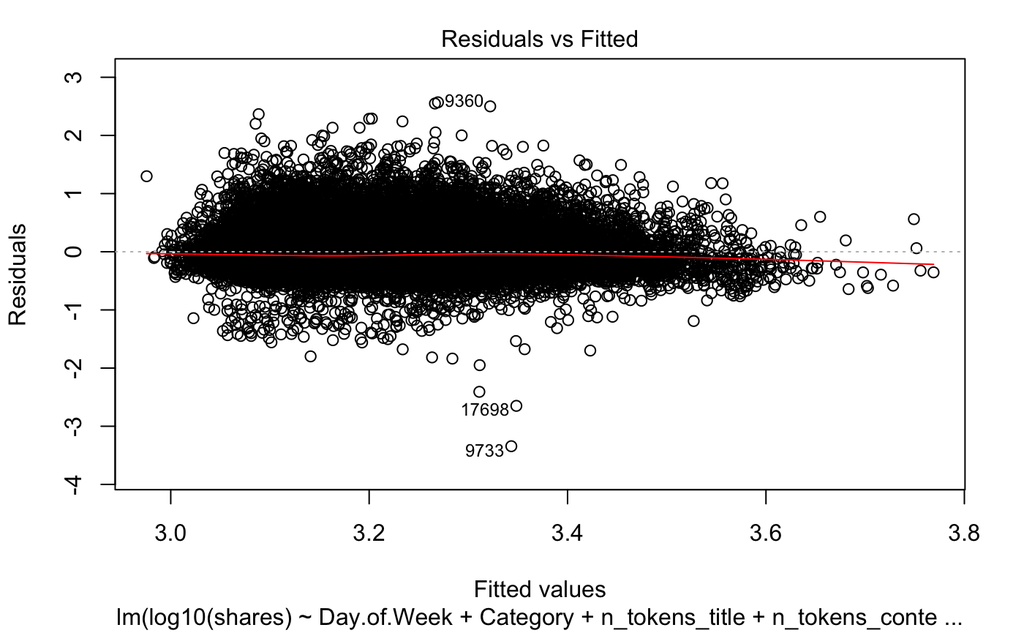

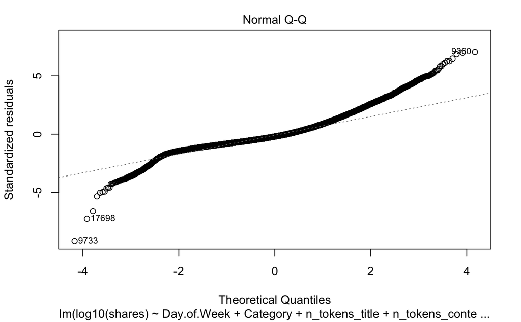

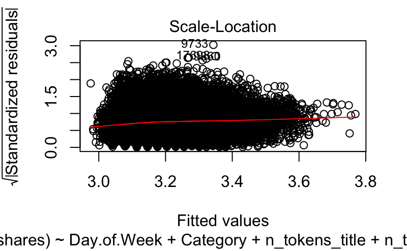

The assumptions of linearity and constant variance appear to be fulfilled for this model.

### Normality assumptions

We can see that in both Q-Q plots, the normality assumption appears to be violated. We can still proceed with the analysis since the number of samples in our dataset is fairly large.